# ExtraaLearn Project

## Context

The EdTech industry has been surging in the past decade immensely, and according to a forecast, the Online Education market would be worth $286.62bn by 2023 with a compound annual growth rate (CAGR) of 10.26% from 2018 to 2023. The modern era of online education has enforced a lot in its growth and expansion beyond any limit. Due to having many dominant features like ease of information sharing, personalized learning experience, transparency of assessment, etc, it is now preferable to traditional education.

In the present scenario due to the Covid-19, the online education sector has witnessed rapid growth and is attracting a lot of new customers. Due to this rapid growth, many new companies have emerged in this industry. With the availability and ease of use of digital marketing resources, companies can reach out to a wider audience with their offerings. The customers who show interest in these offerings are termed as leads. There are various sources of obtaining leads for Edtech companies, like

- The customer interacts with the marketing front on social media or other online platforms.
- The customer browses the website/app and downloads the brochure
- The customer connects through emails for more information.

The company then nurtures these leads and tries to convert them to paid customers. For this, the representative from the organization connects with the lead on call or through email to share further details.

## Objective

ExtraaLearn is an initial stage startup that offers programs on cutting-edge technologies to students and professionals to help them upskill/reskill. With a large number of leads being generated on a regular basis, one of the issues faced by ExtraaLearn is to identify which of the leads are more likely to convert so that they can allocate resources accordingly. You, as a data scientist at ExtraaLearn, have been provided the leads data to:

- Analyze and build an ML model to help identify which leads are more likely to convert to paid customers,
- Find the factors driving the lead conversion process
- Create a profile of the leads which are likely to convert

## Data Description

The data contains the different attributes of leads and their interaction details with ExtraaLearn. The detailed data dictionary is given below.

**Data Dictionary**

- ID: ID of the lead
- age: Age of the lead
- current_occupation: Current occupation of the lead. Values include 'Professional','Unemployed',and 'Student'
- first_interaction: How did the lead first interacted with ExtraaLearn. Values include 'Website', 'Mobile App'
- profile_completed: What percentage of profile has been filled by the lead on the website/mobile app. Values include Low - (0-50%), Medium - (50-75%), High (75-100%)
- website_visits: How many times has a lead visited the website
- time_spent_on_website: Total time spent on the website
- page_views_per_visit: Average number of pages on the website viewed during the visits.
- last_activity: Last interaction between the lead and ExtraaLearn.
  - Email Activity: Seeking for details about program through email, Representative shared information with lead like brochure of program , etc
  - Phone Activity: Had a Phone Conversation with representative, Had conversation over SMS with representative, etc
  - Website Activity: Interacted on live chat with representative, Updated profile on website, etc
- print_media_type1: Flag indicating whether the lead had seen the ad of ExtraaLearn in the Newspaper.
- print_media_type2: Flag indicating whether the lead had seen the ad of ExtraaLearn in the Magazine.
- digital_media: Flag indicating whether the lead had seen the ad of ExtraaLearn on the digital platforms.
- educational_channels: Flag indicating whether the lead had heard about ExtraaLearn in the education channels like online forums, discussion threads, educational websites, etc.
- referral: Flag indicating whether the lead had heard about ExtraaLearn through reference.
- status: Flag indicating whether the lead was converted to a paid customer or not.

## Importing necessary libraries and data

```python
import warnings

warnings.filterwarnings("ignore")
from statsmodels.tools.sm_exceptions import ConvergenceWarning

warnings.simplefilter("ignore", ConvergenceWarning)

# Libraries to help with reading and manipulating data

import pandas as pd
import numpy as np

# Library to split data
from sklearn.model_selection import train_test_split

# libaries to help with data visualization
import matplotlib.pyplot as plt
import seaborn as sns

# Removes the limit for the number of displayed columns
pd.set_option("display.max_columns", None)
# Sets the limit for the number of displayed rows
pd.set_option("display.max_rows", 200)
# setting the precision of floating numbers to 5 decimal points
pd.set_option("display.float_format", lambda x: "%.5f" % x)

# To build model for prediction
import statsmodels.stats.api as sms
from statsmodels.stats.outliers_influence import variance_inflation_factor
import statsmodels.api as sm
from statsmodels.tools.tools import add_constant
from sklearn.linear_model import LogisticRegression
from sklearn.tree import DecisionTreeClassifier
from sklearn.tree import DecisionTreeClassifier, plot_tree


# To tune different models
from sklearn.model_selection import GridSearchCV


# To get diferent metric scores
from sklearn.metrics import (
    f1_score,
    accuracy_score,
    recall_score,
    precision_score,
    confusion_matrix,
    roc_auc_score,
    classification_report,
    precision_recall_curve,
    roc_curve,
    make_scorer,
)
```

## Data Overview

- Observations
- Sanity checks

```python
df = pd.read_csv('ExtraaLearn.csv')
df.head()
```

|  | ID | age | current_occupation | first_interaction | profile_completed | website_visits | time_spent_on_website | page_views_per_visit | last_activity | print_media_type1 | print_media_type2 | digital_media | educational_channels | referral | status |
| --- | --- | --- | --- | --- | --- | --- | --- | --- | --- | --- | --- | --- | --- | --- | --- |
| 0 | EXT001 | 57 | Unemployed | Website | High | 7 | 1639 | 1.86100 | Website Activity | Yes | No | Yes | No | No | 1 |
| 1 | EXT002 | 56 | Professional | Mobile App | Medium | 2 | 83 | 0.32000 | Website Activity | No | No | No | Yes | No | 0 |
| 2 | EXT003 | 52 | Professional | Website | Medium | 3 | 330 | 0.07400 | Website Activity | No | No | Yes | No | No | 0 |
| 3 | EXT004 | 53 | Unemployed | Website | High | 4 | 464 | 2.05700 | Website Activity | No | No | No | No | No | 1 |
| 4 | EXT005 | 23 | Student | Website | High | 4 | 600 | 16.91400 | Email Activity | No | No | No | No | No | 0 |

## Exploratory Data Analysis (EDA)

- EDA is an important part of any project involving data.
- It is important to investigate and understand the data better before building a model with it.
- A few questions have been mentioned below which will help you approach the analysis in the right manner and generate insights from the data.
- A thorough analysis of the data, in addition to the questions mentioned below, should be done.

```python
# Shape of the dataset
print("Shape of the dataset:", df.shape)

# Data types of each column
print("\nData types:\n", df.dtypes)
```

```
Shape of the dataset: (4612, 15)

Data types:
 ID                        object
age                        int64
current_occupation        object
first_interaction         object
profile_completed         object
website_visits             int64
time_spent_on_website      int64
page_views_per_visit     float64
last_activity             object
print_media_type1         object
print_media_type2         object
digital_media             object
educational_channels      object
referral                  object
status                     int64
dtype: object
```

```python
# Descriptive statistics for numerical features
df.describe()
```

|  | age | website_visits | time_spent_on_website | page_views_per_visit | status |
| --- | --- | --- | --- | --- | --- |
| count | 4612.00000 | 4612.00000 | 4612.00000 | 4612.00000 | 4612.00000 |
| mean | 46.20121 | 3.56678 | 724.01127 | 3.02613 | 0.29857 |
| std | 13.16145 | 2.82913 | 743.82868 | 1.96812 | 0.45768 |
| min | 18.00000 | 0.00000 | 0.00000 | 0.00000 | 0.00000 |
| 25% | 36.00000 | 2.00000 | 148.75000 | 2.07775 | 0.00000 |
| 50% | 51.00000 | 3.00000 | 376.00000 | 2.79200 | 0.00000 |
| 75% | 57.00000 | 5.00000 | 1336.75000 | 3.75625 | 1.00000 |
| max | 63.00000 | 30.00000 | 2537.00000 | 18.43400 | 1.00000 |

```python
# Shape and structure
print("Shape of data:", df.shape)
print("\nData Types:\n", df.dtypes)
print("\nMissing Values:\n", df.isnull().sum())
```

```
Shape of data: (4612, 15)

Data Types:
 ID                        object
age                        int64
current_occupation        object
first_interaction         object
profile_completed         object
website_visits             int64
time_spent_on_website      int64
page_views_per_visit     float64
last_activity             object
print_media_type1         object
print_media_type2         object
digital_media             object
educational_channels      object
referral                  object
status                     int64
dtype: object

Missing Values:
 ID                       0
age                      0
current_occupation       0
first_interaction        0
profile_completed        0
website_visits           0
time_spent_on_website    0
page_views_per_visit     0
last_activity            0
print_media_type1        0
print_media_type2        0
digital_media            0
educational_channels     0
referral                 0
status                   0
dtype: int64
```

```
Value counts for 'status':
0   0.70143
1   0.29857
Name: status, dtype: float64
```

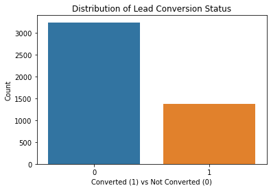

```python
# Target variable distribution
print("Value counts for 'status':")
print(df['status'].value_counts(normalize=True))

# Visualize class balance
sns.countplot(data=df, x='status')
plt.title("Distribution of Lead Conversion Status")
plt.xlabel("Converted (1) vs Not Converted (0)")
plt.ylabel("Count")
plt.show()
```

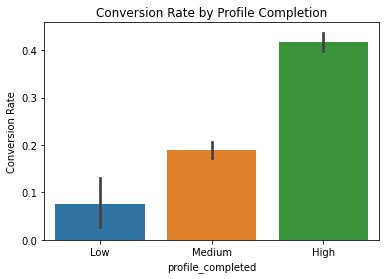

```python
sns.barplot(data=df, x='profile_completed', y='status', order=['Low', 'Medium', 'High'])
plt.title("Conversion Rate by Profile Completion")
plt.ylabel("Conversion Rate")
plt.show()
```

Observation

- Leads with **High profile completion (75–100%)** had the highest conversion rate (~40%)
- Leads with **Medium profile completion (50–75%)** converted at around 20%
- Leads with **Low profile completion (0–50%)** had the lowest conversion rate (less than 10%)

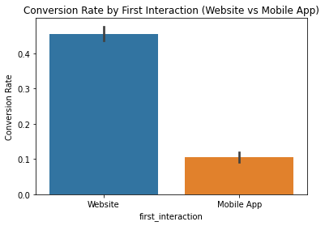

```python
sns.barplot(data=df, x='first_interaction', y='status')
plt.title("Conversion Rate by First Interaction (Website vs Mobile App)")
plt.ylabel("Conversion Rate")
plt.show()
```

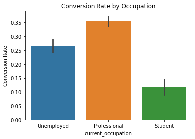

```python
sns.barplot(data=df, x='current_occupation', y='status')
plt.title("Conversion Rate by Occupation")
plt.ylabel("Conversion Rate")
plt.show()
```

> Professionals had the highest conversion rate ~35%, followed by the Unemployed ~25%, while Students had the lowest ~10%.  
> This suggests that professionals are more likely to invest in ExtraaLearn's offerings.

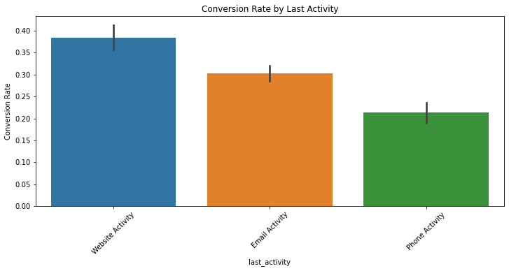

```python
plt.figure(figsize=(12, 5))
sns.barplot(data=df, x='last_activity', y='status')
plt.xticks(rotation=45)
plt.title("Conversion Rate by Last Activity")
plt.ylabel("Conversion Rate")
plt.show()
```

Website activity led to the highest conversion rate, followed by Email ~30%, and Phone activity ~20%. This suggests that self-driven engagement on the website is a strong indicator of conversion.

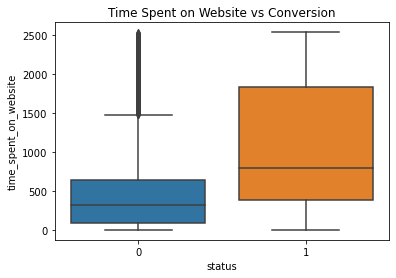

```python
sns.boxplot(data=df, x='status', y='time_spent_on_website')
plt.title("Time Spent on Website vs Conversion")
plt.show()
```

Converted leads (status = 1) spent **more time on the website** on average compared to non-converted leads.  
This suggests that higher engagement time is positively associated with conversion.

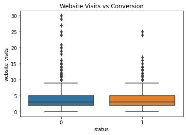

```python
sns.boxplot(data=df, x='status', y='website_visits')
plt.title("Website Visits vs Conversion")
plt.show()
```

[figure not shown]

```python
channel_cols = ['print_media_type1', 'print_media_type2', 'digital_media',
                'educational_channels', 'referral']

conversion_rates = {}

for col in channel_cols:
    rate = df.groupby(col)['status'].mean()
    if 1 in rate:
        conversion_rates[col] = rate[1]
    else:
        conversion_rates[col] = 0

pd.Series(conversion_rates).sort_values(ascending=False).plot(kind='bar')
plt.title("Conversion Rate by Marketing Channel")
plt.ylabel("Conversion Rate")
plt.show()
```

**Questions**